# IBM1090 - Trabalho Final

João Francisco Baiochi, nºUSP 7547674, baiochi@usp.br

November 28, 2015

## Introduction

The aim of this work is to apply the knowledge seen in the [IBM1090 - Pattern Recognition](https://uspdigital.usp.br/jupiterweb/obterDisciplina?sgldis=IBM1090&verdis=2) lectures. Data provided from a previous study was used to perform some analysis, such as unsupervised/supervised clustering, correlation matrix and principal component analysis.  
All the methods and algorithms were computed in [R](https://www.r-project.org/) language, as well as the plots and this document, made with [R Markdown](http://rmarkdown.rstudio.com/).

## Experimental Design

The microRNA microarray design consisting in Naive T cells(CD4+ form) extracted from the umbilical cord of four patients. Each sample collected was them submitted to two different treatments, one with tgfß/atRA to induce the CD4+ into a regulatory T cell (Lu et al., [2011](http://www.ncbi.nlm.nih.gov/pubmed/21931768)), and another with a aAIM-V medium (Invitrogen) for control (CD4med). Thus our experimental design have 12 paired samples, 3 for each patient and 3 classes (Naive, iTreg, CD4med). However, unfortunately the sample from a patient had to be discarded for presenting artifacts in the array, this is why we wont see the label of the sample #3.  
The goal of this previous study was to access global differential expression and validate another analysis, in other words, confirm that some specific microRNAs are more expressed in the iTreg condiction than the controls, ccontributing to increase the evidence that regulating microRNAs expression can induce a Naive T cell into a Treg.

The complete statistical analysis can be read [here](https://raw.githubusercontent.com/baiochi/Agilent-Bioc/master/Reports/Naive-iTreg_microRNA.html). It cotains all the steps from reading data, to normalization and differential expression.

To begin our analysis, first we load the data from the repository:

```r
load(url('https://raw.githubusercontent.com/baiochi/Agilent-Bioc/master/Naive_Cells/diffexprs.rda'))
load(url('https://raw.githubusercontent.com/baiochi/Agilent-Bioc/master/Naive_Cells/tgs.rda'))
load(url('https://raw.githubusercontent.com/baiochi/Agilent-Bioc/master/Naive_Cells/norm.rda'))
```

`tgs` contains the ‘raw’ signal(TotalGeneSignal) used in the statistical analysis  
`nrom` contains the normalized signal by a quantile method(as described in the *limma* package)  
`data` contains the differential expressed miRs with the normalized signal

## Unsupervised Hierarchical Clustering

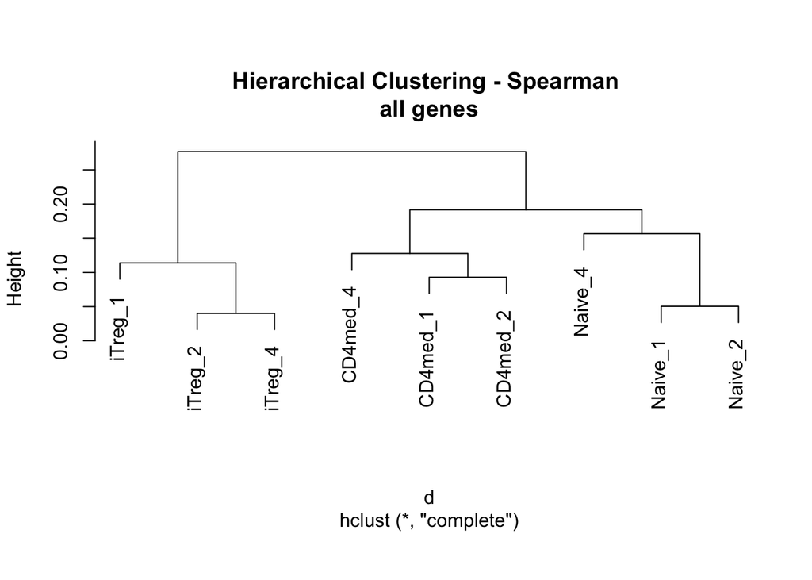

```r
par(oma = c(2, 0, 2, 0))
hierclust(norm$TGS, methdis="spearman", methclu="complete", sel=FALSE)
```

## Supervised Clustering

For the suprevisioned clustering we can plot a heatmap from the differentially expressed microRNAs, using [Euclidean](https://en.wikipedia.org/wiki/Euclidean_distance) method to compute the distance matrix and [Complete-linkage](https://en.wikipedia.org/wiki/Complete-linkage_clustering) method used to perform the hierarchical clustering.  
Highlighted miRs of interest are: hsa−miR−23a−5p, hsa−miR−30a−5p, hsa−miR−636, hsa−miR−1299, hsa−miR−422a, hsa−miR−610.

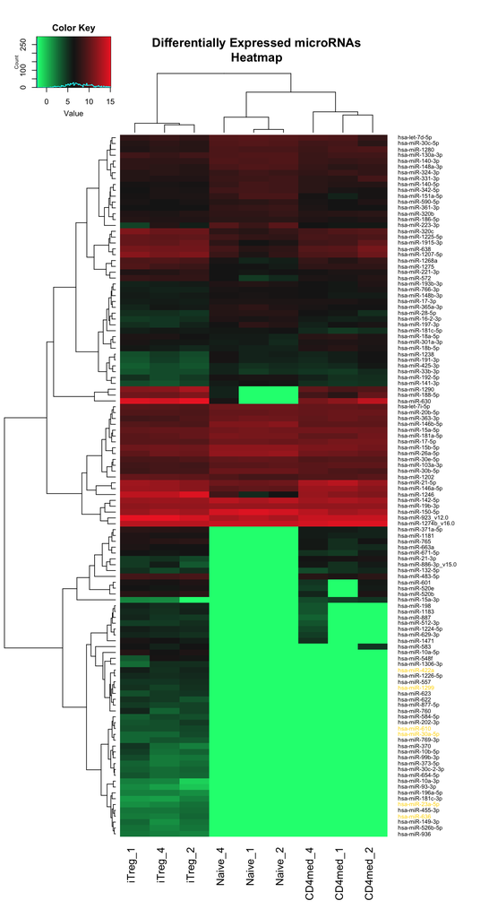

```r
#define palette
rbg = maPalette(low = "springgreen", high = "firebrick2", mid = "grey10", k = 100)
#highlight miRs
hl <- grep(pattern = '23a|-30a|636|1299|422a|610', x = rownames(data))
hlColor <- function(x){
  col <- ''
  for(i in 1:dim(data)[1])
    if(length(col) %in% x){
      col[i-1] <- 'gold'
      col[i] <- 'black'
    }
    else
      col[i] <- 'black'
  return(col)
}
labelColors <- hlColor(hl)
#adjust plot window
par(oma = c(2, 0, 2, 0))
#plot heatmap
heatmap.2(data,
          distfun = function(x) dist(x,method = 'euclidean'),
          hclustfun = function(x) hclust(x,method = 'complete'),
          labCol = colnames(data), labRow = rownames(data),
          scale = "none", symkey=FALSE, symbreaks=FALSE,
          keysize = 1.3, col = rbg, trace = 'none', margins = c(6,10),
          colRow = labelColors, sepcolor = 'black',
          key.title = 'Color Key', main='', lhei=c(1.5, 10))
title(main='Differentially Expressed microRNAs\nHeatmap')
```

A colorblind-friendly version can be seen [here](https://raw.githubusercontent.com/baiochi/Agilent-Bioc/master/Reports/microRNA_Clustering.png), or a more [interactive version](http://htmlpreview.github.io/?https://github.com/baiochi/Agilent-Bioc/blob/master/Reports/Interactive_Heatmap.html).

## Correlation Matrix

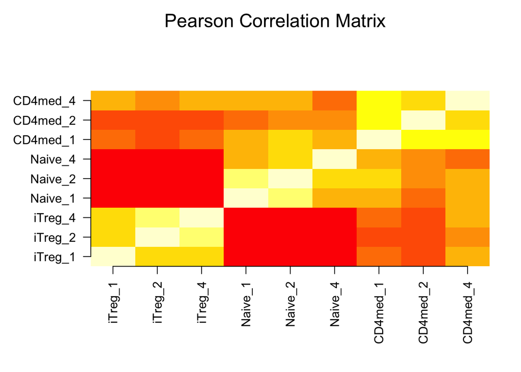

```r
cor.matrix(log2(tgs$TGS), title="Pearson Correlation Matrix")
```

## Principal Component Analysis

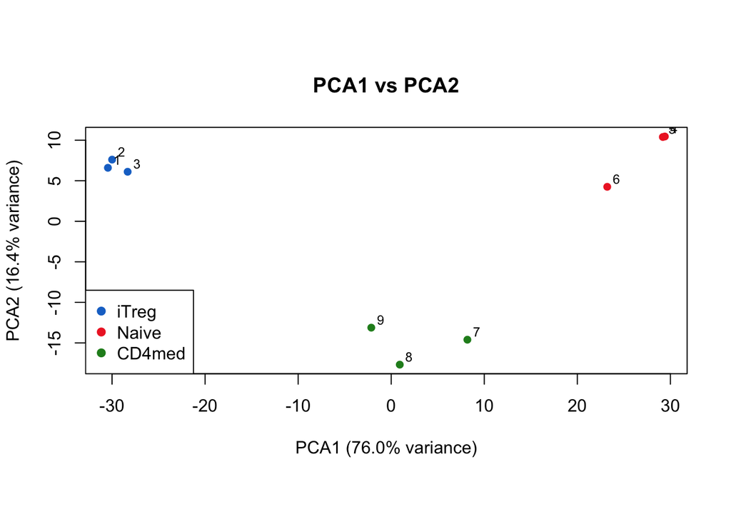

```r
# compute pca
dat.pca = prcomp(t(na.omit(data)))

par(oma = c(2, 0, 2, 0))
plot(main="PCA1 vs PCA2",dat.pca$x[,1:2],pch=16,
     col=c(rep("dodgerblue3",3), rep("firebrick2",3), rep("forestgreen",3)),
     xlab = paste('PCA1', sprintf('(%0.1f%% variance)', summary(dat.pca)$importance[2,1]*100)),
     ylab = paste('PCA2', sprintf('(%0.1f%% variance)', summary(dat.pca)$importance[2,2]*100))
     )
text(x = dat.pca$x[,1]+1, y = dat.pca$x[,2]+1, labels = 1:9, cex=0.75)
legend("bottomleft",legend=c("iTreg","Naive", 'CD4med'),
       col=c("dodgerblue3","firebrick2","forestgreen"),pch = 19)
```

last updated on: Sun Nov 29 01:50:10 2015